# PHB228 Homework 1

Author

A69043689

Published

May 3, 2026

```r
library(tidyverse)
library(bench)
library(palmerpenguins)
library(purrr)
```

# 1 Part 1: Vectorization and Data Structures

## 1.1 1.1 Vectorization

### 1.1.1 a)

```r
vectorized_zscore <- function(x) {
  (x - mean(x, na.rm = TRUE)) / sd(x, na.rm = TRUE)
}

loop_zscore <- function(x) {
  x_mean <- mean(x, na.rm = TRUE)
  x_sd <- sd(x, na.rm = TRUE)
  z <- numeric(length(x))

  for (i in seq_along(x)) {
    z[i] <- (x[i] - x_mean) / x_sd
  }

  z
}

iris_x <- iris$Sepal.Length
head(tibble(
  original = iris_x,
  vectorized = vectorized_zscore(iris_x),
  loop = loop_zscore(iris_x)
))
```

```
# A tibble: 6 × 3
  original vectorized   loop
     <dbl>      <dbl>  <dbl>
1      5.1     -0.898 -0.898
2      4.9     -1.14  -1.14
3      4.7     -1.38  -1.38
4      4.6     -1.50  -1.50
5      5       -1.02  -1.02
6      5.4     -0.535 -0.535
```

```r
all.equal(vectorized_zscore(iris_x), loop_zscore(iris_x))
```

```
[1] TRUE
```

### 1.1.2 b)

```r
zscore_bench <- bench::mark(
  vectorized = vectorized_zscore(iris_x),
  loop = loop_zscore(iris_x),
  iterations = 50,
  check = TRUE
)

zscore_bench |> select(expression, median, `itr/sec`, mem_alloc)
```

```
# A tibble: 2 × 4
  expression   median `itr/sec` mem_alloc
  <bch:expr> <bch:tm>     <dbl> <bch:byt>
1 vectorized   24.7µs    34892.    5.61KB
2 loop         54.1µs    16643.    5.61KB
```

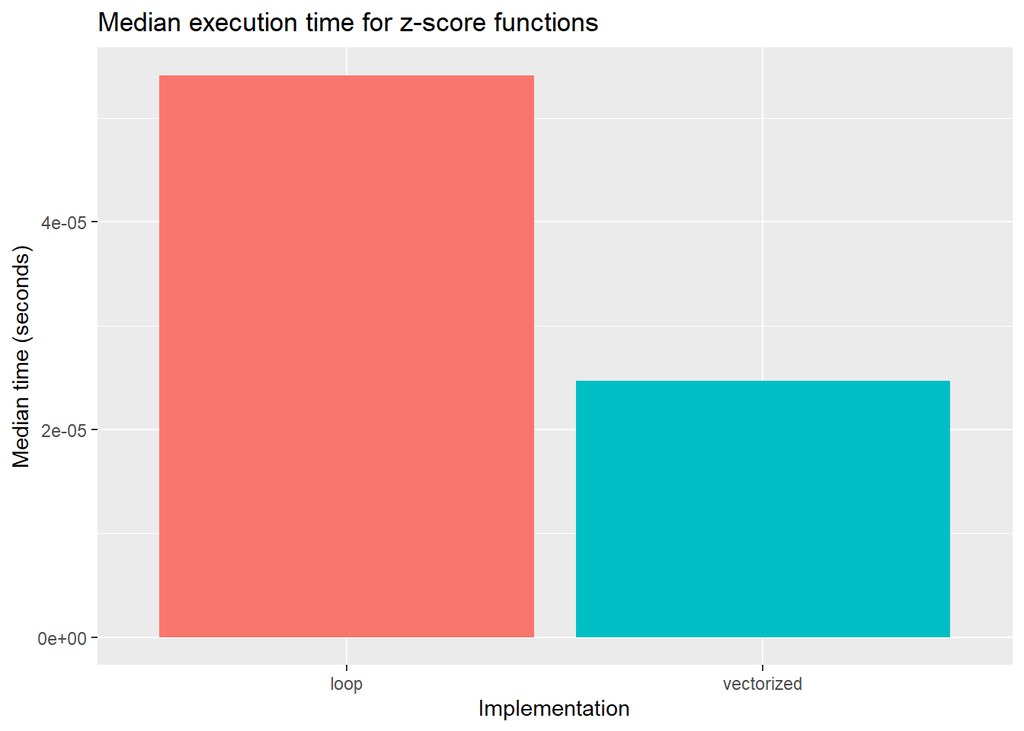

```r
zscore_bench |>
  mutate(
    implementation = as.character(expression),
    median_seconds = as.numeric(median)
  ) |>
  ggplot(aes(x = implementation, y = median_seconds, fill = implementation)) +
  geom_col(show.legend = FALSE) +
  labs(
    title = "Median execution time for z-score functions",
    x = "Implementation",
    y = "Median time (seconds)"
  )
```

### 1.1.3 c)

```r
chick_growth <- ChickWeight |>
  arrange(Chick, Time) |>
  group_by(Chick) |>
  mutate(
    first_weight = first(weight),
    last_weight = last(weight),
    Growth.Rate = (weight - lag(weight)) / (Time - lag(Time)),
    Weight.Gain.Percent = (last_weight - first_weight) / first_weight * 100
  ) |>
  ungroup()

chick_growth |>
  group_by(Diet) |>
  summarize(
    average_growth_rate = mean(Growth.Rate, na.rm = TRUE),
    mean_maximum_weight = mean(tapply(weight, Chick, max)[as.character(unique(Chick))]),
    mean_weight_gain_percent = mean(Weight.Gain.Percent),
    .groups = "drop"
  )
```

```
# A tibble: 4 × 4
  Diet  average_growth_rate mean_maximum_weight mean_weight_gain_percent
  <fct>               <dbl>               <dbl>                    <dbl>
1 1                    5.92                158.                     300.
2 2                    8.32                216.                     432.
3 3                   11.0                 272.                     561.
4 4                    8.91                230.                     465.
```

## 1.2 1.2 Data Structures and Functional Programming

### 1.2.1 a)

```r
penguin_by_species <- split(penguins, penguins$species)

penguin_by_species <- lapply(penguin_by_species, function(df) {
  attr(df, "sample_size") <- nrow(df)
  df
})

map_int(penguin_by_species, ~ attr(.x, "sample_size"))
```

```
   Adelie Chinstrap    Gentoo
      152        68       124
```

### 1.2.2 b)

```r
numeric_means_lapply <- lapply(penguin_by_species, function(df) {
  numeric_cols <- df |> select(where(is.numeric))
  lapply(numeric_cols, mean, na.rm = TRUE)
})

numeric_means_lapply
```

```
$Adelie
$Adelie$bill_length_mm
[1] 38.79139

$Adelie$bill_depth_mm
[1] 18.34636

$Adelie$flipper_length_mm
[1] 189.9536

$Adelie$body_mass_g
[1] 3700.662

$Adelie$year
[1] 2008.013


$Chinstrap
$Chinstrap$bill_length_mm
[1] 48.83382

$Chinstrap$bill_depth_mm
[1] 18.42059

$Chinstrap$flipper_length_mm
[1] 195.8235

$Chinstrap$body_mass_g
[1] 3733.088

$Chinstrap$year
[1] 2007.971


$Gentoo
$Gentoo$bill_length_mm
[1] 47.50488

$Gentoo$bill_depth_mm
[1] 14.98211

$Gentoo$flipper_length_mm
[1] 217.187

$Gentoo$body_mass_g
[1] 5076.016

$Gentoo$year
[1] 2008.081
```

```r
numeric_means_map <- penguin_by_species |>
  map(function(df) {
    df |>
      select(where(is.numeric)) |>
      map_dbl(mean, na.rm = TRUE)
  })

numeric_means_map
```

```
$Adelie
   bill_length_mm     bill_depth_mm flipper_length_mm       body_mass_g
         38.79139          18.34636         189.95364        3700.66225
             year
       2008.01316

$Chinstrap
   bill_length_mm     bill_depth_mm flipper_length_mm       body_mass_g
         48.83382          18.42059         195.82353        3733.08824
             year
       2007.97059

$Gentoo
   bill_length_mm     bill_depth_mm flipper_length_mm       body_mass_g
         47.50488          14.98211         217.18699        5076.01626
             year
       2008.08065
```

### 1.2.3 c)

```r
tapply(penguins$body_mass_g, penguins$species, mean, na.rm = TRUE)
```

```
   Adelie Chinstrap    Gentoo
 3700.662  3733.088  5076.016
```

```r
tapply(
  penguins$body_mass_g,
  list(species = penguins$species, sex = penguins$sex),
  mean,
  na.rm = TRUE
)
```

```
           sex
species       female     male
  Adelie    3368.836 4043.493
  Chinstrap 3527.206 3938.971
  Gentoo    4679.741 5484.836
```

### 1.2.4 d)

```r
x <- c(1, 2, 3, 4)
y <- x

before <- tibble(object = c("x", "y"), value = c(paste(x, collapse = ", "), paste(y, collapse = ", ")))
y[1] <- 99
after <- tibble(object = c("x", "y"), value = c(paste(x, collapse = ", "), paste(y, collapse = ", ")))

list(before = before, after = after)
```

```
$before
# A tibble: 2 × 2
  object value
  <chr>  <chr>
1 x      1, 2, 3, 4
2 y      1, 2, 3, 4

$after
# A tibble: 2 × 2
  object value
  <chr>  <chr>
1 x      1, 2, 3, 4
2 y      99, 2, 3, 4
```

After assigning `y <- x`, both names initially point to the same vector value. When `y[1]` is changed, R creates a modified copy for `y`, so `x` keeps its original values. This copy-on-modify behavior makes ordinary assignment behave safely while avoiding unnecessary copies until a change is made.

### 1.2.5 e)

```r
growing_time <- system.time({
  result_growing <- numeric(0)
  for (i in 1:10000) {
    result_growing <- c(result_growing, i^2)
  }
})

preallocated_time <- system.time({
  result_preallocated <- numeric(10000)
  for (i in 1:10000) {
    result_preallocated[i] <- i^2
  }
})

rbind(growing_vector = growing_time, preallocated = preallocated_time)
```

```
               user.self sys.self elapsed user.child sys.child
growing_vector      0.17      0.2    0.42         NA        NA
preallocated        0.02      0.0    0.02         NA        NA
```

```r
all.equal(result_growing, result_preallocated)
```

```
[1] TRUE
```

The growing-vector version repeatedly allocates a new vector and copies all previous values each time `c()` is called. The preallocated version reserves the needed memory once and fills positions in place, so it avoids thousands of repeated allocations and copies. That is why the preallocated loop is faster and scales better.

# 2 Part 2: Matrix Operations and Decompositions

## 2.1 2.1 Matrix Operations

```r
A <- matrix(c(4, 2, 1, 5), nrow = 2)
B <- matrix(c(3, 1, 0, 2), nrow = 2)
C <- matrix(c(1, 3, 5, 2, 4, 6), nrow = 2)
```

### 2.1.1 a)

```r
A_plus_B <- A + B
A_elementwise_B <- A * B
A_matrix_B <- A %*% B
tA_matrix_C <- t(A) %*% C
A_inverse <- solve(A)

list(
  A_plus_B = A_plus_B,
  A_elementwise_B = A_elementwise_B,
  A_matrix_B = A_matrix_B,
  tA_matrix_C = tA_matrix_C,
  A_inverse = A_inverse
)
```

```
$A_plus_B
     [,1] [,2]
[1,]    7    1
[2,]    3    7

$A_elementwise_B
     [,1] [,2]
[1,]   12    0
[2,]    2   10

$A_matrix_B
     [,1] [,2]
[1,]   13    2
[2,]   11   10

$tA_matrix_C
     [,1] [,2] [,3]
[1,]   10   24   28
[2,]   16   15   34

$A_inverse
           [,1]        [,2]
[1,]  0.2777778 -0.05555556
[2,] -0.1111111  0.22222222
```

`A + B` adds corresponding entries of the two matrices. `A * B` multiplies corresponding entries element by element, while `A %*% B` performs matrix multiplication using row-by-column inner products. `t(A) %*% C` first transposes `A` and then matrix-multiplies by `C`; `solve(A)` returns the inverse matrix of `A`.

### 2.1.2 b)

```r
is_symmetric <- function(mat, tol = .Machine$double.eps^0.5) {
  if (!is.matrix(mat)) {
    stop("Input must be a matrix.")
  }
  if (nrow(mat) != ncol(mat)) {
    stop("Input matrix must be square.")
  }
  isTRUE(all.equal(mat, t(mat), tolerance = tol))
}

tibble(
  matrix = c("A", "B", "t(A) %*% A"),
  symmetric = c(is_symmetric(A), is_symmetric(B), is_symmetric(t(A) %*% A))
)
```

```
# A tibble: 3 × 2
  matrix     symmetric
  <chr>      <lgl>
1 A          FALSE
2 B          FALSE
3 t(A) %*% A TRUE
```

## 2.2 2.2 Eigenvalue Decomposition

```r
M <- matrix(c(4, 2, 2, 3), nrow = 2)
```

### 2.2.1 a)

```r
M_eigen <- eigen(M)
M_eigen
```

```
eigen() decomposition
$values
[1] 5.561553 1.438447

$vectors
           [,1]       [,2]
[1,] -0.7882054  0.6154122
[2,] -0.6154122 -0.7882054
```

### 2.2.2 b)

```r
eigen_checks <- map(seq_along(M_eigen$values), function(i) {
  lambda <- M_eigen$values[i]
  x_vec <- M_eigen$vectors[, i]

  tibble(
    eigenpair = i,
    left_side = list(M %*% x_vec),
    right_side = list(lambda * x_vec),
    matches = isTRUE(all.equal(as.vector(M %*% x_vec), as.vector(lambda * x_vec)))
  )
})

bind_rows(eigen_checks)
```

```
# A tibble: 2 × 4
  eigenpair left_side     right_side matches
      <int> <list>        <list>     <lgl>
1         1 <dbl [2 × 1]> <dbl [2]>  TRUE
2         2 <dbl [2 × 1]> <dbl [2]>  TRUE
```

### 2.2.3 c)

```r
P <- M_eigen$vectors
D <- diag(M_eigen$values)
M_reconstructed <- P %*% D %*% solve(P)

M_reconstructed
```

```
     [,1] [,2]
[1,]    4    2
[2,]    2    3
```

```r
all.equal(M, M_reconstructed)
```

```
[1] TRUE
```

## 2.3 2.3 SVD and QR Decomposition

### 2.3.1 a) SVD

```r
X <- matrix(c(3, 2, 2, 2, 3, -2, 2, -2, 3), nrow = 3)

X_svd <- svd(X)
X_svd
```

```
$d
[1] 5 5 1

$u
              [,1]       [,2]       [,3]
[1,] -1.438522e-16 -0.8164966  0.5773503
[2,] -7.071068e-01 -0.4082483 -0.5773503
[3,]  7.071068e-01 -0.4082483 -0.5773503

$v
           [,1]       [,2]       [,3]
[1,]  0.0000000 -0.8164966 -0.5773503
[2,] -0.7071068 -0.4082483  0.5773503
[3,]  0.7071068 -0.4082483  0.5773503
```

```r
X_rank1 <- X_svd$d[1] * X_svd$u[, 1, drop = FALSE] %*% t(X_svd$v[, 1, drop = FALSE])
frobenius_norm <- norm(X - X_rank1, type = "F")

X_rank1
```

```
     [,1]          [,2]          [,3]
[1,]    0  5.085942e-16 -5.085942e-16
[2,]    0  2.500000e+00 -2.500000e+00
[3,]    0 -2.500000e+00  2.500000e+00
```

```r
frobenius_norm
```

```
[1] 5.09902
```

The rank-1 approximation keeps only the strongest singular direction, so it preserves the largest linear pattern in `X`. The remaining singular directions are discarded, which means smaller-scale variation and structure orthogonal to the dominant direction are lost. The Frobenius norm measures the total size of that discarded information.

### 2.3.2 b) QR and Least Squares

```r
set.seed(228)
n <- 100
x <- runif(n, -5, 5)
y <- 3 + 2 * x + rnorm(n, sd = 1)

design_matrix <- cbind(intercept = 1, x = x)
qr_fit <- qr(design_matrix)
beta_qr <- qr.coef(qr_fit, y)
beta_lm <- coef(lm(y ~ x))

tibble(
  method = c("QR", "lm"),
  intercept = c(beta_qr[1], beta_lm[1]),
  slope = c(beta_qr[2], beta_lm[2])
)
```

```
# A tibble: 2 × 3
  method intercept slope
  <chr>      <dbl> <dbl>
1 QR          2.99  1.95
2 lm          2.99  1.95
```

QR decomposition solves least squares without explicitly forming `(X'X)^{-1}`. This is numerically more stable, especially when predictors are correlated or the design matrix is close to singular. It also provides a direct way to assess matrix rank and solve overdetermined systems efficiently.

# 3 Part 3: Optimization and Simulation

## 3.1 3.1 Gradient Descent

### 3.1.1 a)

```r
rosenbrock <- function(x) {
  (1 - x[1])^2 + 100 * (x[2] - x[1]^2)^2
}
```

### 3.1.2 b)

```r
rosenbrock_grad <- function(x) {
  c(
    -2 * (1 - x[1]) - 400 * x[1] * (x[2] - x[1]^2),
    200 * (x[2] - x[1]^2)
  )
}
```

### 3.1.3 c)

```r
gradient_descent <- function(init, grad_fn, learning_rate = 0.001,
                             max_iter = 10000, tol = 1e-6,
                             fn = rosenbrock) {
  x_current <- init

  for (iter in seq_len(max_iter)) {
    grad <- grad_fn(x_current)
    grad_norm <- sqrt(sum(grad^2))

    if (grad_norm < tol) {
      return(list(solution = x_current, value = fn(x_current), iterations = iter - 1))
    }

    x_current <- x_current - learning_rate * grad
  }

  list(solution = x_current, value = fn(x_current), iterations = max_iter)
}
```

### 3.1.4 d)

```r
gd_result <- gradient_descent(
  init = c(-1.2, 1.0),
  grad_fn = rosenbrock_grad,
  learning_rate = 0.001,
  max_iter = 10000,
  tol = 1e-6
)

gd_result
```

```
$solution
[1] 0.9923558 0.9847394

$value
[1] 5.852761e-05

$iterations
[1] 10000
```

The gradient descent solution is 0.992356, 0.984739, with function value 5.85276^{-5} after 10^{4} iterations.

## 3.2 3.2 Comparison with Built-in Methods

### 3.2.1 a)

```r
bfgs_result <- optim(
  par = c(-1.2, 1.0),
  fn = rosenbrock,
  gr = rosenbrock_grad,
  method = "BFGS"
)

bfgs_result
```

```
$par
[1] 1 1

$value
[1] 9.594956e-18

$counts
function gradient
     110       43

$convergence
[1] 0

$message
NULL
```

### 3.2.2 b)

```r
nelder_mead_result <- optim(
  par = c(-1.2, 1.0),
  fn = rosenbrock,
  method = "Nelder-Mead"
)

optimization_comparison <- tibble(
  method = c("Gradient descent", "BFGS", "Nelder-Mead"),
  x1 = c(gd_result$solution[1], bfgs_result$par[1], nelder_mead_result$par[1]),
  x2 = c(gd_result$solution[2], bfgs_result$par[2], nelder_mead_result$par[2]),
  function_value = c(gd_result$value, bfgs_result$value, nelder_mead_result$value),
  reported_iterations = c(gd_result$iterations, bfgs_result$counts["gradient"], NA),
  function_evaluations = c(NA, bfgs_result$counts["function"], nelder_mead_result$counts["function"])
)

optimization_comparison
```

```
# A tibble: 3 × 6
  method        x1    x2 function_value reported_iterations function_evaluations
  <chr>      <dbl> <dbl>          <dbl>               <dbl>                <int>
1 Gradient … 0.992 0.985       5.85e- 5               10000                   NA
2 BFGS       1.000 1.000       9.59e-18                  43                  110
3 Nelder-Me… 1.00  1.00        8.83e- 8                  NA                  195
```

BFGS reaches the known minimum near `(1, 1)` with a very small function value using far fewer evaluations because it uses gradient and curvature information. Nelder-Mead also gets close to the optimum but usually needs more function evaluations because it does not use derivatives. The fixed-step gradient descent implementation improves steadily but is much slower on the Rosenbrock function’s narrow curved valley, so after 10,000 iterations it is less accurate than the built-in optimizers.

## 3.3 3.3 Simulation Study

### 3.3.1 a)

```r
run_simulation <- function(n_samples, n_reps, dist_type) {
  map_dfr(seq_len(n_reps), function(rep_id) {
    sample_values <- switch(
      dist_type,
      normal = rnorm(n_samples, mean = 0, sd = 1),
      t3 = rt(n_samples, df = 3),
      contaminated = if_else(
        runif(n_samples) < 0.9,
        rnorm(n_samples, mean = 0, sd = 1),
        rnorm(n_samples, mean = 0, sd = 10)
      ),
      stop("Unknown distribution type.")
    )

    tibble(
      replication = rep_id,
      distribution = dist_type,
      mean = mean(sample_values),
      median = median(sample_values),
      trimmed_mean = mean(sample_values, trim = 0.1)
    )
  })
}
```

### 3.3.2 b)

```r
set.seed(228)
simulation_results <- bind_rows(
  run_simulation(30, 1000, "normal"),
  run_simulation(30, 1000, "t3"),
  run_simulation(30, 1000, "contaminated")
)

simulation_summary <- simulation_results |>
  pivot_longer(
    cols = c(mean, median, trimmed_mean),
    names_to = "estimator",
    values_to = "estimate"
  ) |>
  group_by(distribution, estimator) |>
  summarize(
    bias = mean(estimate),
    variance = var(estimate),
    mse = mean(estimate^2),
    .groups = "drop"
  )

simulation_summary
```

```
# A tibble: 9 × 5
  distribution estimator        bias variance    mse
  <chr>        <chr>           <dbl>    <dbl>  <dbl>
1 contaminated mean          0.0364    0.347  0.348
2 contaminated median        0.0101    0.0672 0.0672
3 contaminated trimmed_mean  0.00985   0.0588 0.0589
4 normal       mean          0.00241   0.0317 0.0317
5 normal       median        0.0109    0.0456 0.0457
6 normal       trimmed_mean  0.00290   0.0326 0.0326
7 t3           mean         -0.0260    0.105  0.105
8 t3           median       -0.0148    0.0576 0.0577
9 t3           trimmed_mean -0.0159    0.0566 0.0568
```

### 3.3.3 c)

```r
simulation_summary |>
  arrange(distribution, mse)
```

```
# A tibble: 9 × 5
  distribution estimator        bias variance    mse
  <chr>        <chr>           <dbl>    <dbl>  <dbl>
1 contaminated trimmed_mean  0.00985   0.0588 0.0589
2 contaminated median        0.0101    0.0672 0.0672
3 contaminated mean          0.0364    0.347  0.348
4 normal       mean          0.00241   0.0317 0.0317
5 normal       trimmed_mean  0.00290   0.0326 0.0326
6 normal       median        0.0109    0.0456 0.0457
7 t3           trimmed_mean -0.0159    0.0566 0.0568
8 t3           median       -0.0148    0.0576 0.0577
9 t3           mean         -0.0260    0.105  0.105
```

Under the normal distribution, the sample mean has the lowest or nearly lowest MSE because it uses all observations efficiently when there are no heavy tails or outliers. Under the t distribution with 3 degrees of freedom, the median and trimmed mean are more competitive because they reduce the influence of extreme observations. Under the contaminated normal distribution, the trimmed mean performs especially well because it keeps more information than the median while still downweighting extreme contaminated values. Bias is small for all three estimators because all simulated distributions are centered at zero, so the main performance difference is driven by variance.

# 4 Part 4: Bootstrap Methods

## 4.1 4.1 Bootstrap Confidence Intervals

### 4.1.1 a)

```r
set.seed(42)
returns <- rnorm(50, mean = 0.08, sd = 0.12)
returns <- returns + rexp(50, rate = 20) - 0.05

bootstrap_mean <- function(x, B = 2000, conf = 0.95) {
  theta_hat <- mean(x)
  n <- length(x)
  boot_means <- replicate(B, mean(sample(x, size = n, replace = TRUE)))
  alpha <- 1 - conf
  se <- sd(boot_means)

  percentile <- quantile(boot_means, probs = c(alpha / 2, 1 - alpha / 2), names = FALSE)
  basic <- 2 * theta_hat - rev(percentile)
  normal <- theta_hat + qnorm(c(alpha / 2, 1 - alpha / 2)) * se

  list(
    estimate = theta_hat,
    se = se,
    boot_means = boot_means,
    intervals = tibble(
      method = c("percentile", "basic", "normal"),
      lower = c(percentile[1], basic[1], normal[1]),
      upper = c(percentile[2], basic[2], normal[2])
    )
  )
}

set.seed(228)
boot_returns <- bootstrap_mean(returns, B = 2000)
boot_returns$estimate
```

```
[1] 0.08251953
```

```r
boot_returns$se
```

```
[1] 0.0218318
```

```r
boot_returns$intervals
```

```
# A tibble: 3 × 3
  method      lower upper
  <chr>       <dbl> <dbl>
1 percentile 0.0403 0.125
2 basic      0.0405 0.125
3 normal     0.0397 0.125
```

### 4.1.2 b)

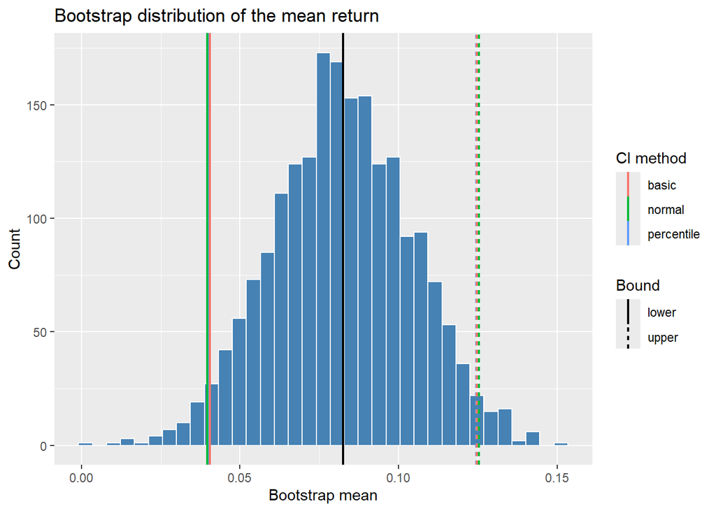

```r
boot_plot_data <- tibble(boot_mean = boot_returns$boot_means)
ci_lines <- boot_returns$intervals |>
  pivot_longer(cols = c(lower, upper), names_to = "bound", values_to = "value")

ggplot(boot_plot_data, aes(x = boot_mean)) +
  geom_histogram(bins = 35, color = "white", fill = "steelblue") +
  geom_vline(data = ci_lines, aes(xintercept = value, color = method, linetype = bound), linewidth = 0.8) +
  geom_vline(xintercept = boot_returns$estimate, color = "black", linewidth = 0.8) +
  labs(
    title = "Bootstrap distribution of the mean return",
    x = "Bootstrap mean",
    y = "Count",
    color = "CI method",
    linetype = "Bound"
  )
```

The percentile interval is appropriate here because it uses the empirical bootstrap distribution directly and does not require a strong normality assumption. The returns include exponential noise, so the sampling distribution can be slightly asymmetric. The normal interval is easy to interpret but can be less reliable when the bootstrap distribution is skewed. The basic interval is also useful, but its reflection around the observed estimate can be less intuitive for skewed data.

## 4.2 4.2 Bootstrap Hypothesis Testing

### 4.2.1 a)

```r
set.seed(123)
control <- rnorm(40, mean = 10, sd = 2)
treatment <- rnorm(40, mean = 11.5, sd = 2)

bootstrap_ttest <- function(control, treatment, B = 2000) {
  observed_diff <- mean(treatment) - mean(control)
  pooled_mean <- mean(c(control, treatment))

  control_null <- control - mean(control) + pooled_mean
  treatment_null <- treatment - mean(treatment) + pooled_mean

  boot_diffs <- replicate(B, {
    boot_control <- sample(control_null, length(control_null), replace = TRUE)
    boot_treatment <- sample(treatment_null, length(treatment_null), replace = TRUE)
    mean(boot_treatment) - mean(boot_control)
  })

  list(
    observed_diff = observed_diff,
    boot_diffs = boot_diffs,
    p_value = mean(abs(boot_diffs) >= abs(observed_diff))
  )
}

set.seed(228)
boot_test <- bootstrap_ttest(control, treatment, B = 2000)
boot_test$observed_diff
```

```
[1] 1.396202
```

```r
boot_test$p_value
```

```
[1] 5e-04
```

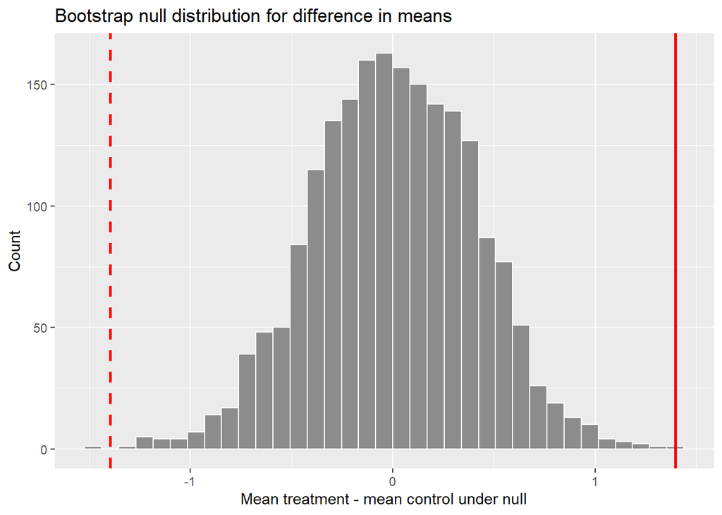

```r
ggplot(tibble(diff = boot_test$boot_diffs), aes(x = diff)) +
  geom_histogram(bins = 35, color = "white", fill = "gray55") +
  geom_vline(xintercept = boot_test$observed_diff, color = "red", linewidth = 1) +
  geom_vline(xintercept = -boot_test$observed_diff, color = "red", linewidth = 1, linetype = "dashed") +
  labs(
    title = "Bootstrap null distribution for difference in means",
    x = "Mean treatment - mean control under null",
    y = "Count"
  )
```

### 4.2.2 b)

```r
t_test_result <- t.test(treatment, control)

tibble(
  method = c("Bootstrap", "Welch t-test"),
  observed_difference = c(boot_test$observed_diff, diff(rev(t_test_result$estimate))),
  p_value = c(boot_test$p_value, t_test_result$p.value)
)
```

```
# A tibble: 2 × 3
  method       observed_difference p_value
  <chr>                      <dbl>   <dbl>
1 Bootstrap                   1.40 0.0005
2 Welch t-test                1.40 0.00121
```

The bootstrap and Welch t-test both indicate a statistically meaningful positive difference between the treatment and control means for these simulated data. Their p-values may differ slightly because the bootstrap uses the empirical resampling distribution rather than the theoretical t approximation. The bootstrap approach is useful when normality or equal-variance assumptions are questionable, and it can be adapted to statistics whose standard errors are harder to derive analytically. The t-test remains efficient and simple when its assumptions are reasonable.